# Neighbor2Neighbor Program Evlauation

Joseph Feldblum

2025-07-02

# Exploratory analysis

Distribution of treatment and canvass_result in data

```r
table(dat$treatment, dat$canvass_result)
```

```
##
##     NOT_HOME NOT_VISITED OPPOSITION_VOTER SPOKE_TO
##   0        0       40395                0        0
##   1     8815       64926              288     7690
```

So the majority of treatment group are coded as “NOT_VISITED”

Let’s check the raw pct voting in each group

| treat_canv_res | n | pct_voting |
| --- | --- | --- |
| 0_NOT_VISITED | 40395 | 0.7458349 |
| 1_NOT_HOME | 8815 | 0.7163925 |
| 1_NOT_VISITED | 64926 | 0.7494070 |
| 1_OPPOSITION_VOTER | 288 | 0.6701389 |
| 1_SPOKE_TO | 7690 | 0.7876463 |

ok, sanity check: same pct of “not visited” voted in treatment and control conditions

## Effect of age

Let’s get a sense of voting rates by age:

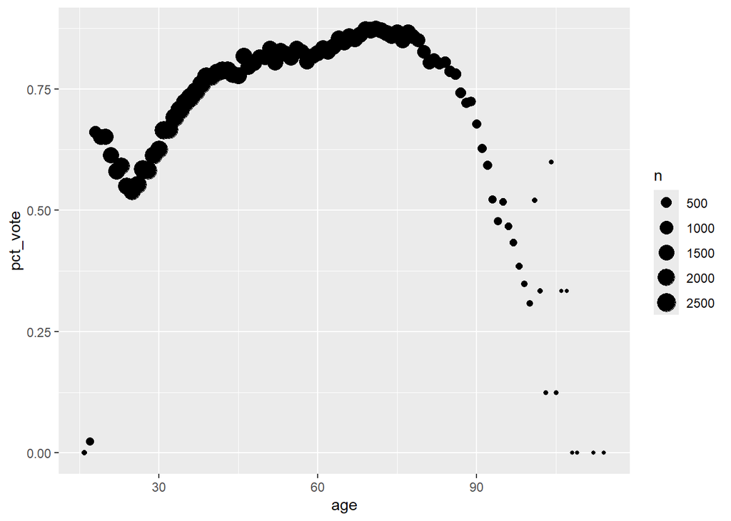

```r
dat %>%
  mutate(age = round(age)) %>%
  group_by(age) %>%
  summarize(n = n(),
            pct_vote = mean(voted)) %>%
  ggplot(aes(x = age, y = pct_vote, size = n)) +
  geom_point() +
  scale_size_continuous()
```

16 and 17 year olds unsurprisingly have voting rates at or near 0. Also we have some suspiciously old ages here, probably should truncate

Let’s look at the counts and voting rates of the youngest voters:

```r
dat %>%
  filter(age < 18) %>%
  group_by(round(age)) %>%
  summarize(n = n(),
            pct_vote = mean(voted),
            n_voted = sum(voted),
            n_treatment = sum(treatment),
            n_treatment_voted = sum(treatment*voted)) %>%
  as.data.frame()
```

| round(age) | n | pct_vote | n_voted | n_treatment | n_treatment_voted |
| --- | --- | --- | --- | --- | --- |
| 16 | 24 | 0.00000000 | 0 | 15 | 0 |
| 17 | 169 | 0.02366864 | 4 | 114 | 2 |

There are 4 total voters under 18 (presumably coding error or turned 18 between canvassing and election). Simplest to just exclude kids under 18

And for the oldest ages:

```r
dat %>%
  mutate(age = round(age)) %>%
  group_by(age) %>%
  summarize(n = n(),
            pct_vote = mean(voted)) %>%
  as.data.frame() %>%
  tail(25)
```

|  | age | n | pct_vote |
| --- | --- | --- | --- |
| 73 | 88 | 413 | 0.7215496 |
| 74 | 89 | 376 | 0.7234043 |
| 75 | 90 | 317 | 0.6782334 |
| 76 | 91 | 298 | 0.6275168 |
| 77 | 92 | 268 | 0.5932836 |
| 78 | 93 | 180 | 0.5222222 |
| 79 | 94 | 199 | 0.4773869 |
| 80 | 95 | 149 | 0.5167785 |
| 81 | 96 | 137 | 0.4671533 |
| 82 | 97 | 120 | 0.4333333 |

[output cut: 15 more lines]

What’s up with NA aged individuals?

```r
dat %>% filter(is.na(age)) %>% count(treatment, canvass_result, voted)
```

| treatment | canvass_result | voted | n |
| --- | --- | --- | --- |
| 0 | NOT_VISITED | 0 | 377 |
| 0 | NOT_VISITED | 1 | 110 |
| 1 | NOT_HOME | 0 | 98 |
| 1 | NOT_HOME | 1 | 15 |
| 1 | NOT_VISITED | 0 | 567 |
| 1 | NOT_VISITED | 1 | 213 |
| 1 | OPPOSITION_VOTER | 0 | 1 |
| 1 | OPPOSITION_VOTER | 1 | 1 |
| 1 | SPOKE_TO | 0 | 59 |
| 1 | SPOKE_TO | 1 | 18 |

These people seem to be voting at a lower rate than the overall sample, without more knowledge of the sample I’ll exclude them too.

Generally, though, it looks like we have a quadratic relationship between age and pct voted, which should be reflected in our model

## Effect of race:

```r
dat %>%
  group_by(race) %>%
  summarize(n = n(),
            pct_vote = mean(voted))
```

| race | n | pct_vote |
| --- | --- | --- |
| AFAM | 16092 | 0.6749316 |
| ASIAN | 6622 | 0.6884627 |
| HISPANIC | 11137 | 0.6497261 |
| NATIVE | 164 | 0.5548780 |
| WHITE | 82433 | 0.7909332 |
| NA | 5666 | 0.6006001 |

Very very few native voters in sample unfortunately

There are also some NAs, change coding to UNK so NA race individuals aren’t dropped in analysis

```r
dat =
  dat %>%
  mutate(race = replace_na(race, "UNK"))
```

## Partisan score and turnout score

Let’s get a look at the distribution of the partisanship score and turnout score data:

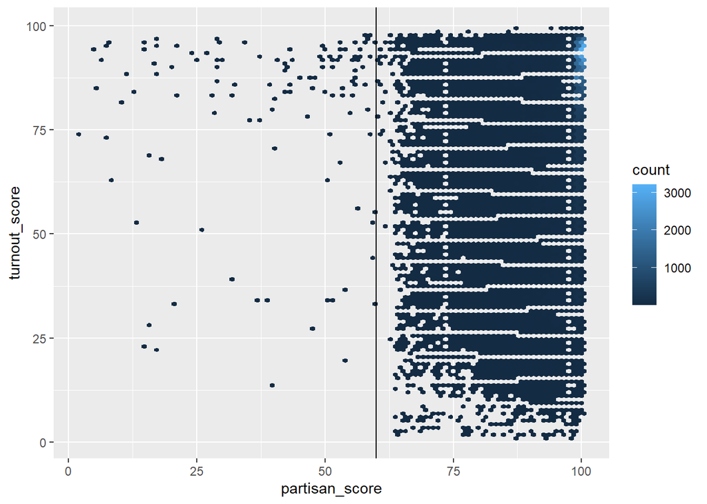

```r
dat %>%
  ggplot(aes(x = partisan_score, y = turnout_score)) +
  geom_hex(bins = 100) +
  geom_vline(xintercept = 60)
```

So it looks like we have Very few individuals in the sample with a partisanship score below 60. What’s the distribution of canvassing results and voting behavior for them?

```r
dat %>%
  filter(partisan_score < 60) %>%
  count(treatment, canvass_result)
```

| treatment | canvass_result | n |
| --- | --- | --- |
| 0 | NOT_VISITED | 42 |
| 1 | NOT_HOME | 4 |
| 1 | NOT_VISITED | 70 |
| 1 | SPOKE_TO | 6 |

The vast majority of voters in the sample have a partisanship score of 60 or above, making it appear that a minimum score was used as a criterion for inclusion. There are only 122 individuals in the sample with partisan scores below 60. Therefore, to help with model convergence and interpretability, I’ll exclude individuals with partisanship scores below 60.

## Does volunteer enthusiasm matter?

Because some volunteers asked for multiple assignments, I wondered if more enthusiastic volunteers might be more successful. First, we’ll look to see if there’s an overall effect of the count of unique assignment ids (i.e. the number of assignments these volunteers took on) on voting rates:

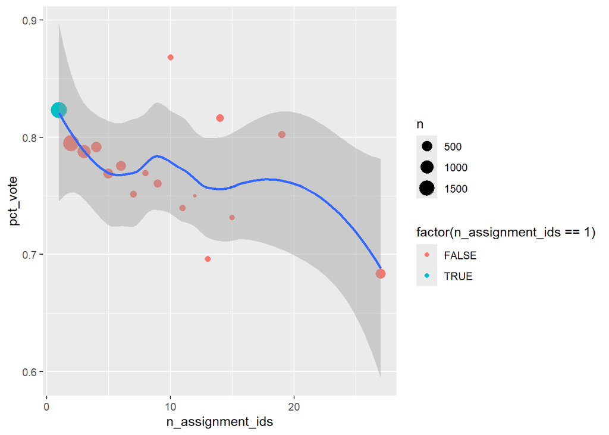

```r
dat %>%
  group_by(canvasser_id) %>%
  mutate(n_assignment_ids = length(unique(assignment_id)),
            n_voters = n()) %>%
  ungroup() %>%
  filter(canvass_result == "SPOKE_TO") %>%
  group_by(n_assignment_ids) %>%
  summarize(pct_vote = mean(voted),
            n = n()) %>%
  ggplot(aes(x = n_assignment_ids, y = pct_vote)) +
  geom_point(aes(color = factor(n_assignment_ids == 1), size = n)) + scale_size_continuous() +
  geom_smooth()
```

Surprisingly, it seems that volunteers who took on more assignments were *less* effective!

OK, but what about if we compare just those volunteers who completed one assignment to those who completed more than one?

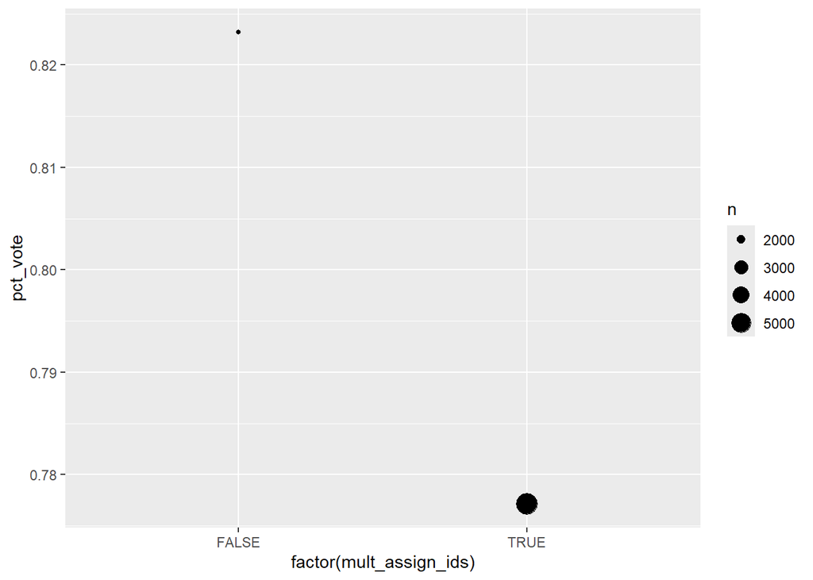

```r
dat %>%
  group_by(canvasser_id) %>%
  mutate(mult_assign_ids = length(unique(assignment_id)) > 1) %>%
  ungroup() %>%
  filter(canvass_result == "SPOKE_TO") %>%
  group_by(mult_assign_ids) %>%
  summarize(pct_vote = mean(voted),
            n = n()) %>%
  ggplot(aes(x = factor(mult_assign_ids), y = pct_vote, size = n)) +
  geom_point()
```

Same surprising result! So the most enthusiastic volunteers may not be the most effective

## Household effects

I wasn’t sure if households were all coded as “spoken to” if someone in the house was, or if different people in a household could have different canvassing success codes. Let’s see:

```r
dat %>%
  group_by(household_id) %>%
  summarize(household_size = n(),
         n_contacted = sum(canvass_result == "SPOKE_TO")) %>%
  ungroup() %>%
  filter(household_size > 1) %>%
  count(household_size, n_contacted)
```

| household_size | n_contacted | n |
| --- | --- | --- |
| 2 | 0 | 15907 |
| 2 | 2 | 1148 |
| 3 | 0 | 5428 |
| 3 | 3 | 438 |
| 4 | 0 | 2209 |
| 4 | 4 | 182 |
| 5 | 0 | 428 |
| 5 | 5 | 43 |

So if anyone is contacted in the household, the whole household is considered “spoken_to”. therefore, no need to add a term for “someone in household spoken to” for some that are coded otherwise